# 242a3ae8-4f6f-4df6-a10d-0648f7d3ea5e

#### Шаг 4. Портрет пользователя

```python
na_data = actual_data.query('na_sales > 0')
eu_data = actual_data.query('eu_sales > 0')
jp_data = actual_data.query('jp_sales > 0')
```

| platform | na_sales |
| --- | --- |
| X360 | 140.05 |
| PS4 | 108.74 |
| PS3 | 103.38 |
| XOne | 93.12 |
| 3DS | 55.31 |

```
[<AxesSubplot:ylabel='na_sales'>]
```

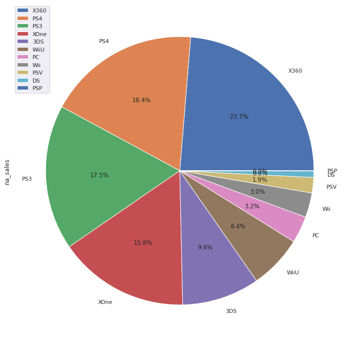

```python
#составим круговые диаграмы так как они наиболее наглядные
na_data_pivot = na_data.pivot_table(index='platform', values='na_sales', aggfunc='sum').sort_values('na_sales', ascending=False)
display(na_data_pivot.head())
print(na_data_pivot.plot(kind = 'pie', subplots=True, figsize = (12,14), autopct='%1.1f%%'))
```

| platform | eu_sales |
| --- | --- |
| PS4 | 141.09 |
| PS3 | 106.86 |
| X360 | 74.52 |
| XOne | 51.59 |
| 3DS | 42.64 |

```
[<AxesSubplot:ylabel='eu_sales'>]
```

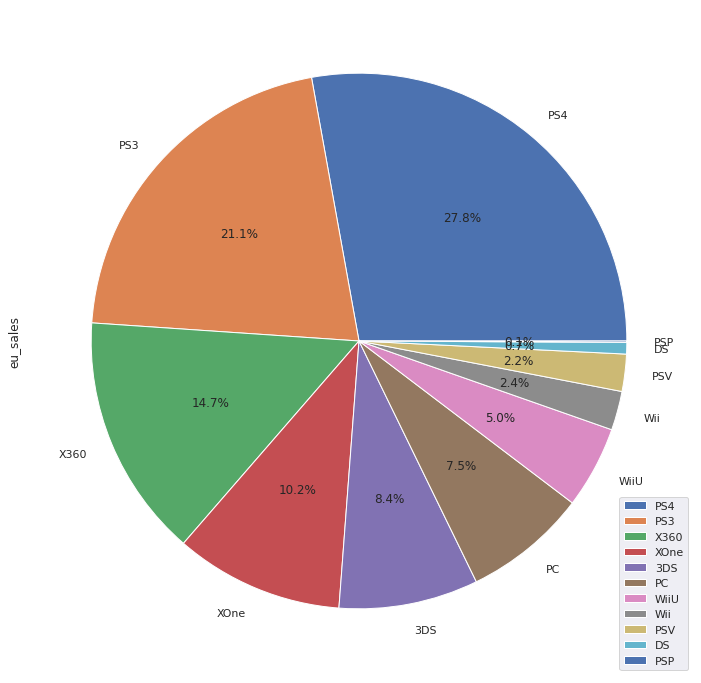

```python
eu_data_pivot = eu_data.pivot_table(index='platform', values='eu_sales', aggfunc='sum').sort_values('eu_sales', ascending=False)
display(eu_data_pivot.head())
print(eu_data_pivot.plot(kind = 'pie', subplots=True, figsize = (12,14), autopct='%1.1f%%'))
```

| platform | jp_sales |
| --- | --- |
| 3DS | 87.79 |
| PS3 | 35.29 |
| PSV | 21.04 |
| PS4 | 15.96 |
| WiiU | 13.01 |

```
[<AxesSubplot:ylabel='jp_sales'>]
```

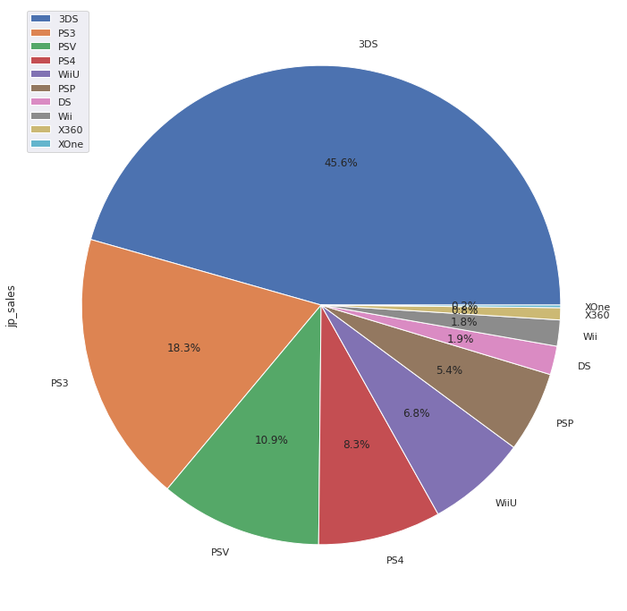

```python
jp_data_pivot = jp_data.pivot_table(index='platform', values='jp_sales', aggfunc='sum').sort_values('jp_sales', ascending=False)
display(jp_data_pivot.head())
print(jp_data_pivot.plot(kind = 'pie', subplots=True, figsize = (12,14), autopct='%1.1f%%'))
```

```python
print(na_data.pivot_table(index='genre', values='na_sales', aggfunc='sum').sort_values('na_sales', ascending=False).head())
print()
print(eu_data.pivot_table(index='genre', values='eu_sales', aggfunc='sum').sort_values('eu_sales', ascending=False).head())
print()
print(jp_data.pivot_table(index='genre', values='jp_sales', aggfunc='sum').sort_values('jp_sales', ascending=False).head())
```

```
              na_sales
genre
Action          177.84
Shooter         144.77
Sports           81.53
Role-Playing     64.00
Misc             38.19

              eu_sales
genre
Action          159.34
Shooter         113.47
Sports           69.09
Role-Playing     48.53
Racing           27.29

              jp_sales
genre
Role-Playing     65.44
Action           52.80
Misc             12.86
Simulation       10.41
Fighting          9.44
```

```
array([<AxesSubplot:ylabel='jp_sales'>], dtype=object)
```

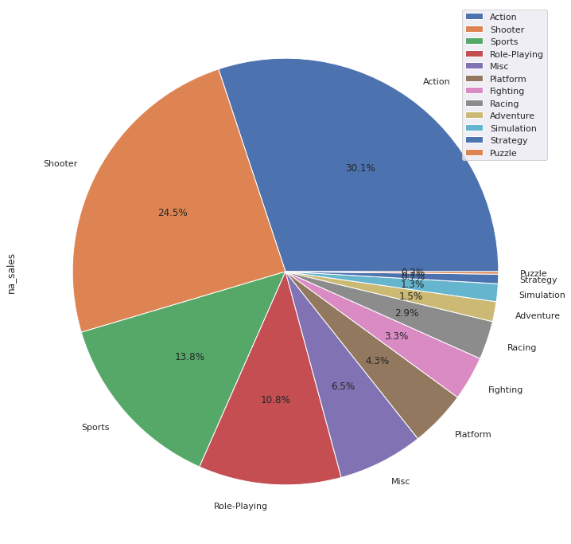

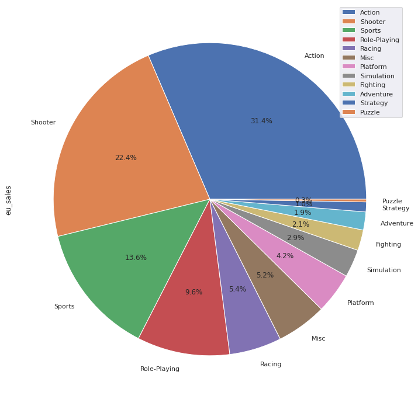

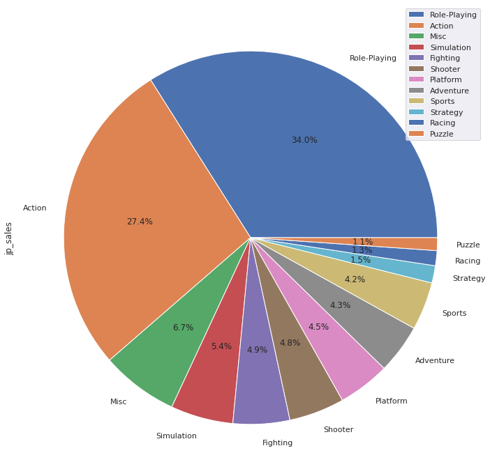

```python
na_data.pivot_table(index='genre', values='na_sales', aggfunc='sum').sort_values('na_sales', ascending=False).plot(kind = 'pie', subplots=True, figsize = (12,14), autopct='%1.1f%%')
eu_data.pivot_table(index='genre', values='eu_sales', aggfunc='sum').sort_values('eu_sales', ascending=False).plot(kind = 'pie', subplots=True, figsize = (12,14), autopct='%1.1f%%')
jp_data.pivot_table(index='genre', values='jp_sales', aggfunc='sum').sort_values('jp_sales', ascending=False).plot(kind = 'pie', subplots=True, figsize = (12,14), autopct='%1.1f%%')
```

```python
print(na_data.pivot_table(index='rating', values='eu_sales', aggfunc='sum').sort_values('eu_sales', ascending=False).head())
print()
print(eu_data.pivot_table(index='rating', values='eu_sales', aggfunc='sum').sort_values('eu_sales', ascending=False).head())
print()
print(jp_data.pivot_table(index='rating', values='jp_sales', aggfunc='sum').sort_values('jp_sales', ascending=False).head())
```

```
           eu_sales
rating
M            192.06
E            107.04
no rating     85.68
E10+          53.44
T             50.46

           eu_sales
rating
M            193.96
E            113.03
no rating     91.50
E10+          55.37
T             52.96

           jp_sales
rating
no rating    108.84
E             28.33
T             26.02
M             21.20
E10+           8.19
```

```
array([<AxesSubplot:ylabel='jp_sales'>], dtype=object)
```

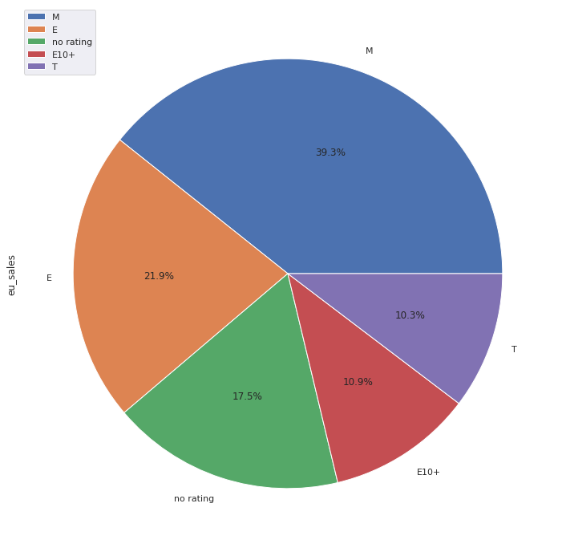

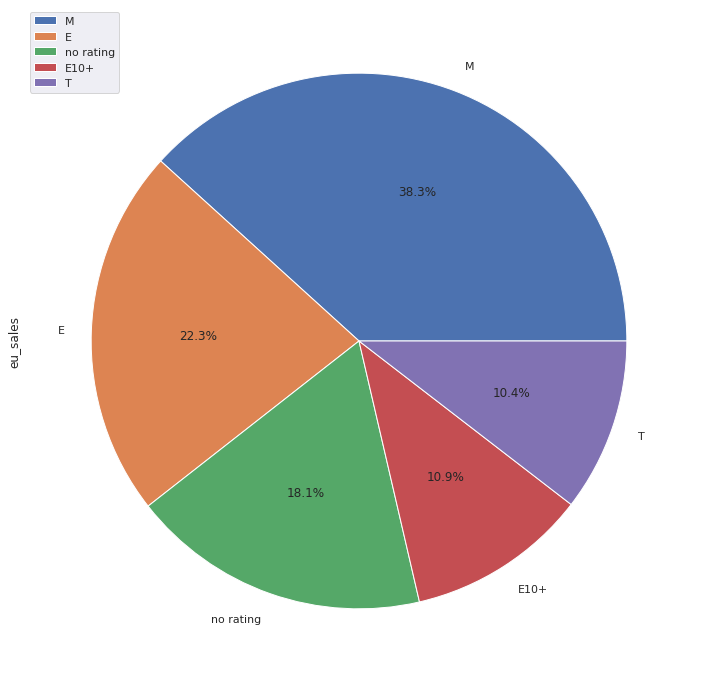

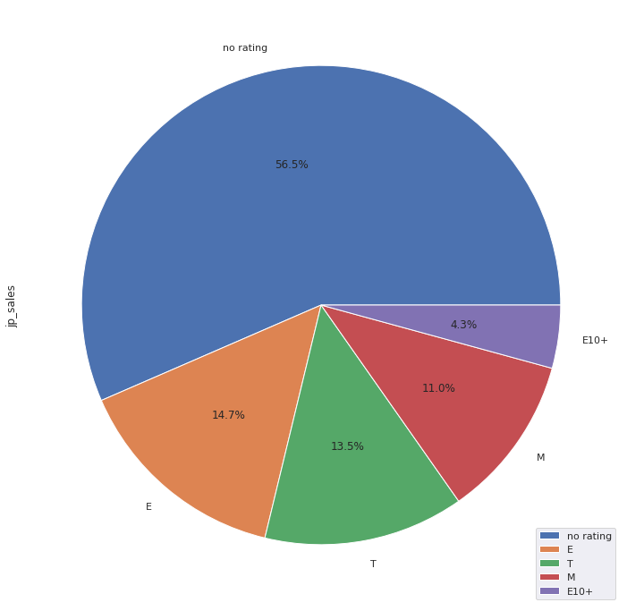

```python
na_data.pivot_table(index='rating', values='eu_sales', aggfunc='sum').sort_values('eu_sales', ascending=False).head().plot(kind = 'pie', subplots=True, figsize = (12,14), autopct='%1.1f%%')
eu_data.pivot_table(index='rating', values='eu_sales', aggfunc='sum').sort_values('eu_sales', ascending=False).head().plot(kind = 'pie', subplots=True, figsize = (12,14), autopct='%1.1f%%')
jp_data.pivot_table(index='rating', values='jp_sales', aggfunc='sum').sort_values('jp_sales', ascending=False).head().plot(kind = 'pie', subplots=True, figsize = (12,14), autopct='%1.1f%%')
```

<div class="alert alert-info"; style="border-left: 7px solid SteelBlue">

#### Шаг 5. Проверка гипотез

<div class="alert alert-info"; style="border-left: 7px solid SteelBlue">

##### 🎓 Комментарий от студента (синий)

Проводим проверку гипотезы о равенстве средних двух генеральных совокупностей.

- Нулевая гипотеза: Средние пользовательские рейтинги платформ Xbox One и PC одинаковые
- Альтернативная гипотеза: Средние пользовательские рейтинги платформ Xbox One и PC различаются

</div>

```python
XboxOne = actual_data.query('platform == "XOne" and user_score != 0')['user_score'].dropna()
PC =  actual_data.query('platform == "PC"and user_score != 0')['user_score'].dropna()
```

```
count    182.000000
mean       6.521429
std        1.380941
min        1.600000
25%        5.800000
50%        6.800000
75%        7.500000
max        9.200000
Name: user_score, dtype: float64
```

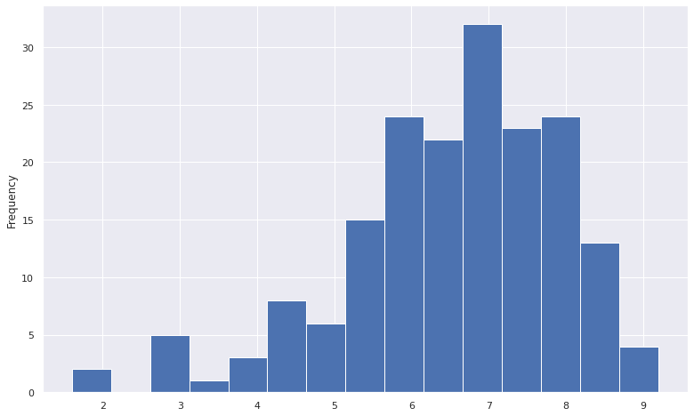

```python
#посмотрим на распределение по Xbox и PC
display(XboxOne.describe())
XboxOne.plot(kind='hist', bins = 15, figsize = (13,8))
```

```
count    206.000000
mean       6.428641
std        1.664465
min        1.400000
25%        5.500000
50%        6.800000
75%        7.700000
max        9.300000
Name: user_score, dtype: float64
```

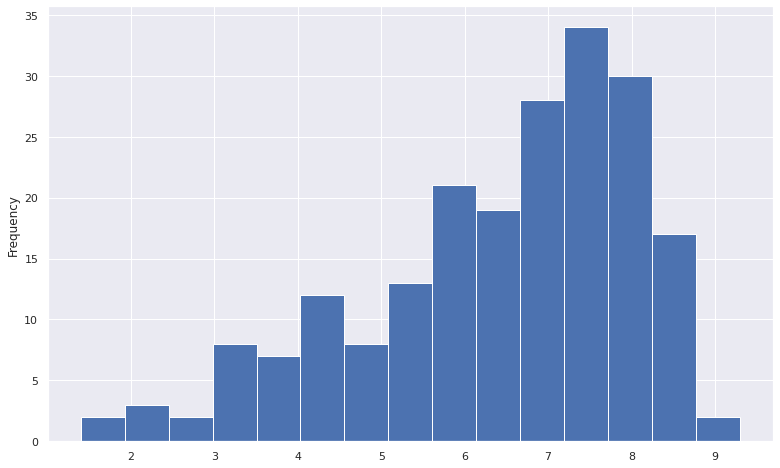

```python
display(PC.describe())
PC.plot(kind='hist', bins = 15, figsize = (13,8))
```

```python
alpha = 0.05

results = st.ttest_ind(XboxOne, PC)

print('p-значение:', results.pvalue)

if (results.pvalue < alpha):
    print("Отвергаем нулевую гипотезу")
else:
    print("Не получилось отвергнуть нулевую гипотезу")
```

```
p-значение: 0.5535080500643661
Не получилось отвергнуть нулевую гипотезу
```

```python
print("доверительный интервал для Xbox:", st.t.interval(alpha=0.95, df=len(XboxOne)-1, loc=np.mean(XboxOne), scale=st.sem(XboxOne)))
print("доверительный интервал для PC:", st.t.interval(alpha=0.95, df=len(PC)-1, loc=np.mean(PC), scale=st.sem(PC)))
```

```
доверительный интервал для Xbox: (6.319452023663737, 6.723405119193408)
доверительный интервал для PC: (6.19999632991511, 6.657285223482945)
```

<div class="alert alert-info"; style="border-left: 7px solid SteelBlue">

##### 🎓 Комментарий от студента (синий)

В ходе проверки мы не смогли отвергнуть нулевую гипотезу, видим что доверительный интревал по рейтингам Xbox и PC схожи.

</div>

<div class="alert alert-info"; style="border-left: 7px solid SteelBlue">

##### 🎓 Комментарий от студента (синий)

Проводим проверку гипотезы о равенстве средних двух генеральных совокупностей.

- Нулевая гипотеза: Средние пользовательские рейтинги жанров Action и Sports одинаковые.
- Альтернативная гипотеза: Средние пользовательские рейтинги жанров Action и Sports различаются.

</div>

```python
Action = actual_data.query('genre == "Action" and user_score != 0')['user_score'].dropna()
Sports = actual_data.query('genre == "Sports" and user_score != 0')['user_score'].dropna()
```

```
count    523.000000
mean       6.825048
std        1.374440
min        1.600000
25%        6.250000
50%        7.100000
75%        7.800000
max        9.100000
Name: user_score, dtype: float64
```

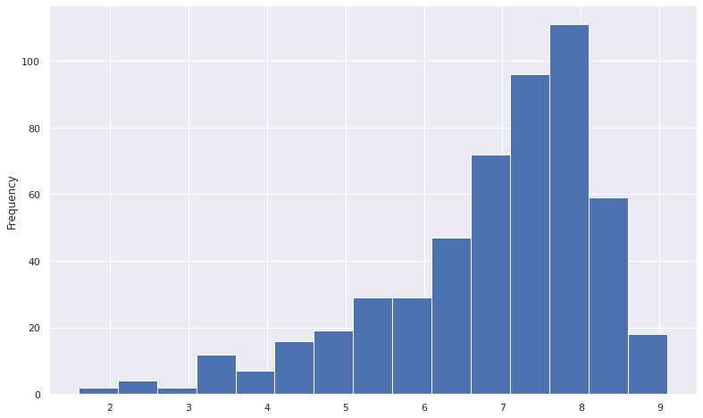

```python
display(Action.describe())
Action.plot(kind='hist', bins = 15, figsize = (13,8))
```

```
count    195.000000
mean       5.455897
std        1.738646
min        0.200000
25%        4.300000
50%        5.700000
75%        6.800000
max        8.800000
Name: user_score, dtype: float64
```

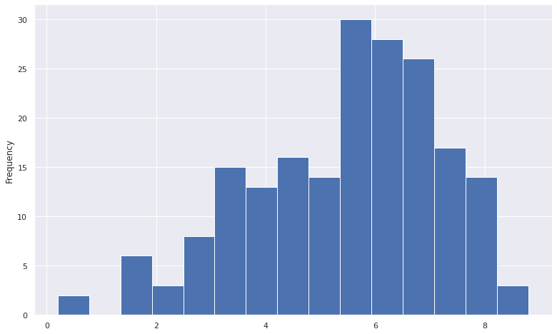

```python
display(Sports.describe())
Sports.plot(kind='hist', bins = 15, figsize = (13,8))
```

```python
alpha = 0.05

results = st.ttest_ind(Action, Sports)

print('p-значение:', results.pvalue)

if (results.pvalue < alpha):
    print("Отвергаем нулевую гипотезу")
else:
    print("Не получилось отвергнуть нулевую гипотезу")
```

```
p-значение: 3.7163089460934874e-26
Отвергаем нулевую гипотезу
```

```python
print("доверительный интервал для Action:", st.t.interval(alpha=0.95, df=len(Action)-1, loc=np.mean(Action), scale=st.sem(Action)))
print("доверительный интервал для Sports:", st.t.interval(alpha=0.95, df=len(Sports)-1, loc=np.mean(Sports), scale=st.sem(Sports)))
```

```
доверительный интервал для Action: (6.706980124635769, 6.943115477658686)
доверительный интервал для Sports: (5.210336255032036, 5.701458616762837)
```

<div class="alert alert-info"; style="border-left: 7px solid SteelBlue">

##### 🎓 Комментарий от студента (синий)

В ходе проверки видим что p-значение недостаточно высокое для подтверждения нулевой гипотезы, отвергаем нулевую гипотезу, видим что доверительный интревал по рейтингам Action и Sports различаются

</div>

#### Шаг 6. Общий вывод

<div class="alert alert-info"; style="border-left: 7px solid SteelBlue">

##### 🎓 Комментарий от студента (синий)

В ходе проделанной работы было выполнено:

- Изучены данные, выявлены аномалии и пропущенные значения.
- Проведена предобработка данных: замена столбцов, заполнение пропусков, удаление дубликатов и т.д.
- Проведен исследовательский анализ по данным и подготовлены актуальные данные, определены средний срок жизни платформ, изучены зависимость продаж от оценок критиков и пользователей, выявлены популярные жанры.
- Составлены портреты пользователей для купных регионов продаж, выявлены их предпочтения.
- Выполнены проверки гипотез.

Рынок игр сейчас находится на спаде, поэтому необходимо внимательно относится к таким факторам как жанр игры, для какого она региона делается, на какой платформе ее выпускать. Перспективно ориентироваться на американский и европейский регион, выбирать экшены шутеры и спортивные игры, что бы они выходили на разных актуальных платформах. Составлен портрет пользователя по регионам: Самые популярные платформы (топ-5). NA: X360, PS4, PS3, XOne, 3DS - Cеверная Америка EU: PS4, PS3, X360, XOne, 3DS - Европа JP: 3DS, PS3, PSV, PS4, WiiU - Япония Самые популярные жанры (топ-5) NA: Action, Shooter, Sports, Role-Playing, Misc - Cеверная Америка  
EU: Action, Shooter, Sports, Role-Playing, Racing - Европа JP: Role-Playing, Action, Misc, Simulation, Fighting - Япония Видно что лидирующие позиции занимает Action хоть по графикам и так же видно что в среднем и медианно продажи выше у Shooter жанра. Так же стоит внимательно относится к оценкам критиков, зависимость продаж от оценок прямопропорцианальная - от отзывов критиков слабая но ближе к средней, а от отзывов пользователей значительно слабее, чем критиков, во многих её почти нет.

</div>